# project_2021_12659

2022-12-17

```r
library(tidyverse)
library(hms)
library(lubridate)
library(modelr)
options(na.action = na.warn)

dir <- ("C:\\Workspace\\scl\\final")
file_list <- list.files(dir)
```

# Q1

```r
file_list_demo <- file_list[str_detect(file_list, "DEMO")]
demo <- data.frame()
for (file in file_list_demo){
  temp <- haven::read_xpt(paste(dir, file, sep ="\\"))
  demo <- bind_rows(demo, temp)
}

demo <- demo %>% select(SEQN, RIAGENDR, RIDAGEYR, RIDRETH3)

demo$RIAGENDR <- as.factor(demo$RIAGENDR)
demo$RIDRETH3 <- as.factor(demo$RIDRETH3)

demo_count <- demo %>% group_by(RIDRETH3) %>% summarise(count = n()) %>% arrange(desc(count))
demo$RIDRETH3 <- factor(demo$RIDRETH3, levels = demo_count$RIDRETH3)
demo <- demo %>% arrange(RIDRETH3)
```

# Q2

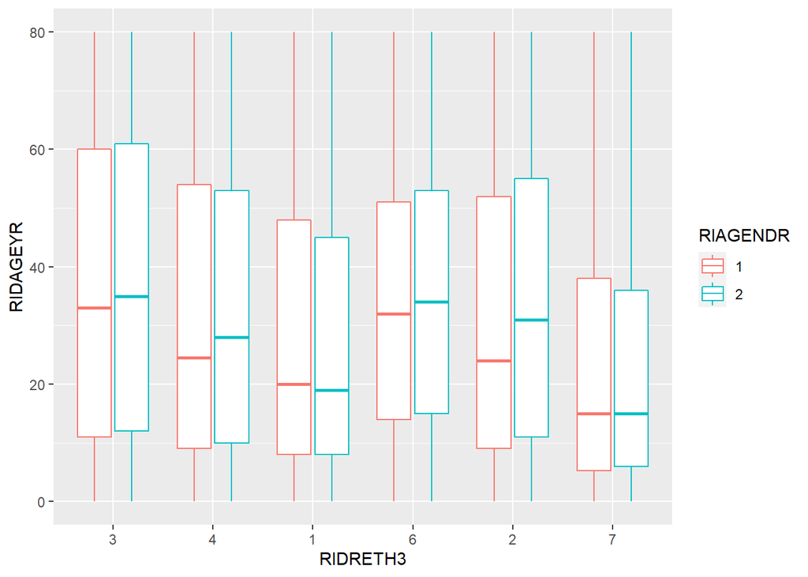

```r
demo %>% ggplot(aes(x = RIDRETH3, y = RIDAGEYR, color = RIAGENDR)) +
  geom_boxplot()
```

#Q3

```r
bp_mean <- function(x){
  try(x <- as.numeric(x), silent =  TRUE)
  x <- ifelse(x == 0, runif(1, 1, 10), x)
  (x <- na.omit(x))
  if (length(x) >= 3) {
    mean(x)
  }
  else{
   NA
  }
}
test <- c(0, 50, 80, 130, NA, "a")
test2 <- c(3, 5, NA)
bp_mean(test)
```

```
## [1] 66.12598
```

```r
bp_mean(test2)
```

```
## [1] NA
```

# Q4

```r
bp_high <- function(detail, mean1, mean2){
  ifelse(is.na(mean1), NA, ifelse(is.na(mean2), NA,
    if (detail == "high"){
      ifelse(mean1 >= 130 | mean2 >= 80, TRUE, FALSE)
    }
    else if(detail == "low") {
      ifelse(mean1 <= 90| mean2 <= 60, TRUE, FALSE)
    }))
  }

bp_high(detail = "high", c(82.2777, 100, NA), c(2.5, 800, NA))
```

```
## [1] FALSE  TRUE    NA
```

```r
bp_high(detail = "low", NA, 100)
```

```
## [1] NA
```

# Q5

```r
file_list_bpx <- file_list[str_detect(file_list, "BPX")]
bpx <- data.frame()
for (file in file_list_bpx){
  temp <- haven::read_xpt(paste(dir, file, sep ="\\"))
  bpx <- bind_rows(bpx, temp)
}

bpx1 <- bpx %>% select(BPXSY1, BPXSY2, BPXSY3, BPXSY4) #%>% mutate(mean_dia = apply(bpx11, bp_mean))
bpx$mean_sys = apply(bpx1, 1, bp_mean)

bpx2 <- bpx %>% select(BPXDI1, BPXDI2, BPXDI3, BPXDI4)
bpx$mean_dia = apply(bpx2, 1, bp_mean)

bpx <- bpx %>% mutate(hyperten = bp_high(detail = "high", mean_sys, mean_dia),
         hypoten = bp_high(detail = "low", mean_sys, mean_dia))

count_bpx <- bpx %>% group_by(hyperten, hypoten) %>% summarise(count = n())
count_bpx
```

```
## # A tibble: 5 × 3
## # Groups:   hyperten [3]
##   hyperten hypoten count
##   <lgl>    <lgl>   <int>
## 1 FALSE    FALSE    9474
## 2 FALSE    TRUE     5386
## 3 TRUE     FALSE    5744
## 4 TRUE     TRUE      764
## 5 NA       NA       6693
```

고혈압 6508명, 저혈압 6150명, 고혈압이면서 동시에 저혈압인 사람 764명이다.

# Q6

```r
file_list_dpq <- file_list[str_detect(file_list, "DPQ")]
dpq <- data.frame()
for (file in file_list_dpq){
  temp <- haven::read_xpt(paste(dir, file, sep ="\\"))
  dpq <- bind_rows(dpq, temp)
}

dpq[dpq == 7] <- NA
dpq[dpq == 9] <- NA
dpq1 <- select(dpq, num_range("DPQ", seq(10, 90, by = 10), width = 3))
dpq$sum = rowSums(dpq1, na.rm = T)
dpq$severity <- cut(dpq$sum,
                    breaks = c(0, 4, 9, 14, 19, 27),
                    right = TRUE,
                    labels = c("None-minimal", "Mild", "Moderate", "Moderately Severe", "Severe"),
                    include.lowest =  TRUE)
table(dpq$severity)
```

```
##
##      None-minimal              Mild          Moderate Moderately Severe
##             13199              2592               874               371
##            Severe
##               156
```

# Q7

```r
slq1314 <- haven::read_xpt("SLQ_H.XPT") %>% select(SEQN, SLD010H, SLQ050) %>% rename( "SLD012"= "SLD010H")
slq1516 <- haven::read_xpt("SLQ_I.XPT") %>% select(SEQN, SLD012, SLQ050, SLQ300, SLQ310)
slq1718 <- haven::read_xpt("SLQ_J.XPT") %>% select(SEQN, SLD012, SLQ050, SLQ300, SLQ310)
slq <- full_join(slq1314, slq1516)
slq <- full_join(slq, slq1718)
slq$SLQ300[slq$SLQ300 == 99999] <- NA
slq$SLQ300[slq$SLQ300 == 77777] <- NA
slq$SLQ300 <- parse_time(slq$SLQ300)

slq$SLQ310[slq$SLQ310 == 99999] <- NA
slq$SLQ310[slq$SLQ310 == 77777] <- NA
slq$SLQ310 <- parse_time(slq$SLQ310)

slq$SLQ050[slq$SLQ050 == 9] <- NA
slq$SLQ050[slq$SLQ050 == 7] <- NA
slq$SLQ050 <- ifelse(slq$SLQ050 == 1, 'Yes', ifelse(slq$SLQ050 == 2, 'No', NA))
slq$SLQ050 <- as.factor(slq$SLQ050)
summary(slq)
```

```
##       SEQN            SLD012        SLQ050         SLQ300
##  Min.   : 73557   Min.   : 2.000   No  :14109   Length:18952
##  1st Qu.: 81030   1st Qu.: 6.500   Yes : 4832   Class1:hms
##  Median : 88463   Median : 7.500   NA's:   11   Class2:difftime
##  Mean   : 88398   Mean   : 7.482                Mode  :numeric
##  3rd Qu.: 95771   3rd Qu.: 8.000
##  Max.   :102956   Max.   :99.000
##                   NA's   :84
##     SLQ310
##  Length:18952
##  Class1:hms
##  Class2:difftime
##  Mode  :numeric
##
##
##
```

# Q8

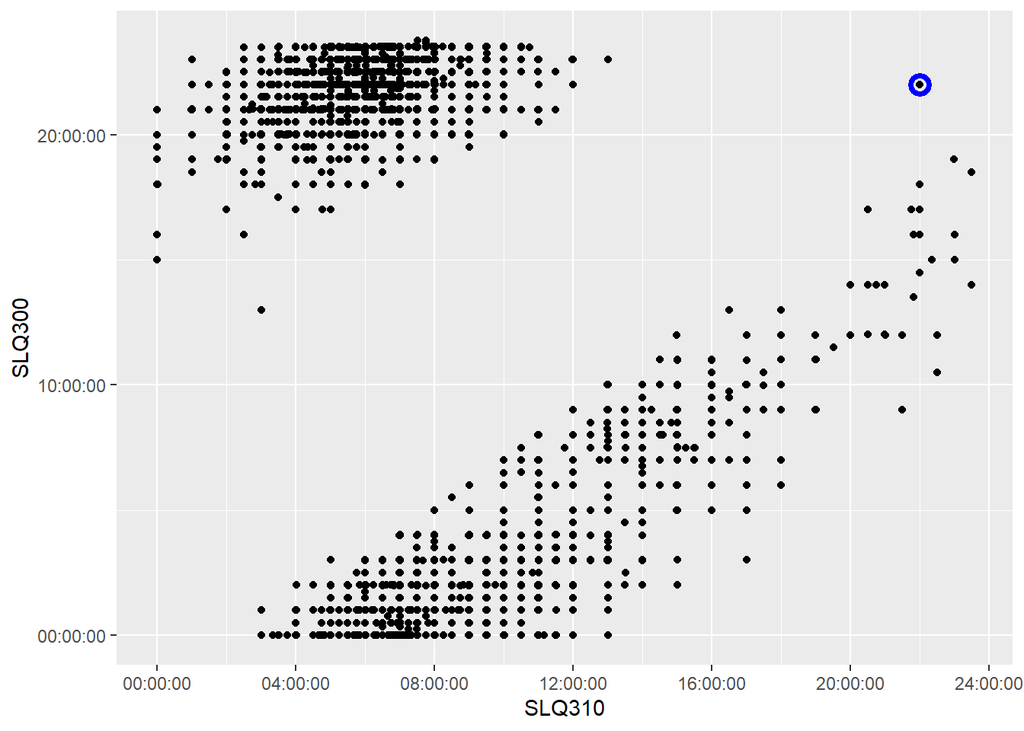

```r
outlier <- slq %>% filter(SLQ310 == SLQ300)
slq %>% ggplot(aes(x = SLQ310, y = SLQ300)) + geom_point(position = "jitter") + geom_point(size = 3, shape = 1,color = "blue", data = outlier, stroke = 2)
```

기상시간과 취침시간이 동일하기 때문이다.

# Q9

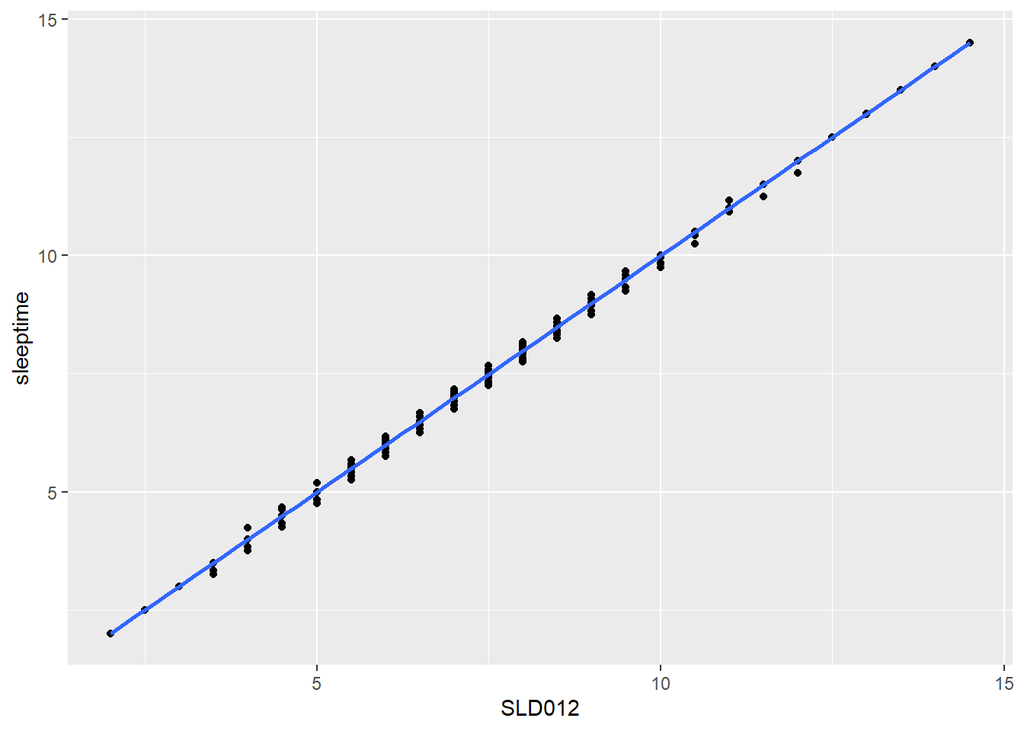

```r
slq <- slq %>% mutate(sleeptime = ifelse(SLQ310 >= SLQ300,
                             abs(SLQ310 - SLQ300)/3600, (parse_time("24:00") - SLQ300 + SLQ310)/3600))

slq %>% filter(SLD012 < 50) %>% ggplot(aes(x = SLD012, y = sleeptime)) + geom_point() + geom_smooth()
```

수면시간이 99시간인 이상치 제거하였다. 평소 수면시간과 거의 일치하였습니다.

# Q10

```r
slq2 <- slq %>% rename("sleep" = "SLQ300", "wake" = "SLQ310") %>% gather(sleep, wake, key = 'sleep/wake', value = 'time') %>% na.omit() %>% group_by(time, `sleep/wake`, SLQ050) %>% summarise(mean = mean(sleeptime))
```

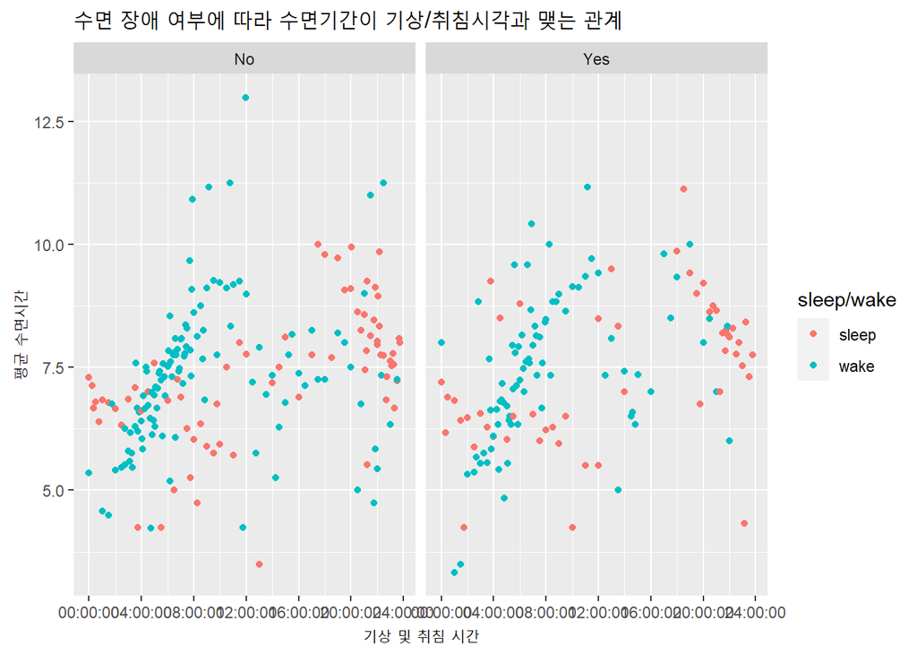

```r
slq2 %>% ggplot(aes(x = time, y= mean)) +
  geom_point(aes(color = `sleep/wake`)) +
  facet_wrap(vars(SLQ050)) +
  labs(title = "수면 장애 여부에 따라 수면기간이 기상/취침시각과 맺는 관계", x = "기상 및 취침 시간", y = "평균 수면시간")
```

한 사람의 기상시간과 취침사간을 분리하였기 때문에 동일한 삶에 대한 둘 간의 관계를 파악하기 어렵다. 또한, 이상치에 주의해야 한다.

# Q11

```r
file_list_bmx <- file_list[str_detect(file_list, "BMX")]
bmx <- data.frame()
for (file in file_list_bmx){
  temp <- haven::read_xpt(paste(dir, file, sep ="\\"))
  bmx <- bind_rows(bmx, temp)
}

bmx <- bmx %>% select(SEQN, BMXBMI) %>% inner_join(demo) %>% inner_join(bpx) %>% inner_join(slq) %>% inner_join(dpq)
nrow(bmx)
```

```
## [1] 17192
```

17192명의 응답자가 포함되었다.

# Q12

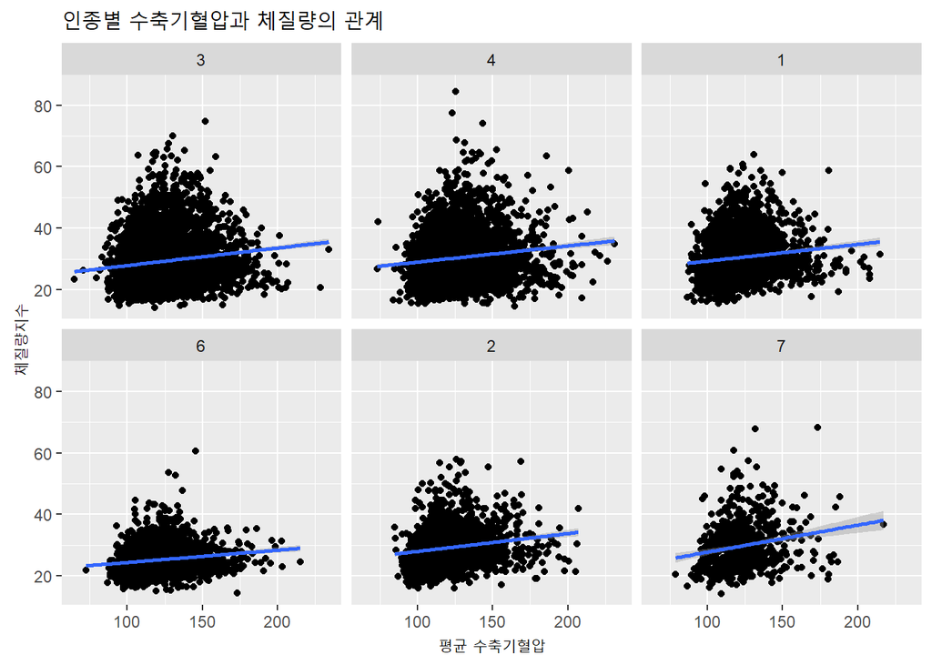

```r
bmx$RIAGENDR <- as.factor(bmx$RIAGENDR)
bmx$RIAGENDR <- ifelse(bmx$RIAGENDR == 1, 'Male', ifelse(bmx$RIAGENDR == 2, 'Female', NA))
bmx %>% ggplot(aes(x = mean_sys, y = BMXBMI)) + geom_point() + facet_wrap(vars(RIDRETH3)) + geom_smooth(method = "lm") +
  labs(title = "인종별 수축기혈압과 체질량의 관계", x = "평균 수축기혈압", y = "체질량지수")
```

6인종 모두 체질량지수와 평균 수축기 혈압간의 양의 상관관계를 보였다. 체질량지수와 수축기 혈압간에는 분명한 관계가 존재할 것으로 보인다. 그래프에서 또한 주목할만한 점은 인종 6(Non-Hispanic Asian)의 체질량 지수가 다른 인종에 비해 눈에띄게 낮은 분포를 보였다는 것이다. 그리고 각 인종마다 수축기 혈압의 분포는 유사해보인다. 따라서 인종과 수축기 혈압은 모종의 관계가 있으리라 생각하지 않는다.

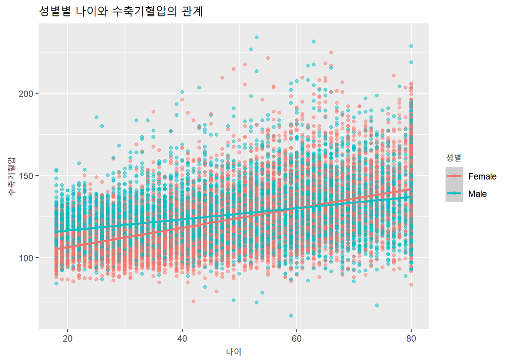

```r
bmx %>% ggplot(aes(x = RIDAGEYR, y = mean_sys, color = RIAGENDR)) + geom_point(alpha = 0.5) + geom_smooth(method = "lm") + labs(x = "나이", y = "수축기혈압", title =  "성별별 나이와 수축기혈압의 관계", color = "성별")
```

성별에 따른 수축기 혈압은 60대 미만에선 남성이 높았으나, 60대가 넘어가면서 여성의 수축기 혈압이 급격히 상승하는 모습을 보였다. 또한 나이가 증가함에 따라 수축기 혈압 역시 상승하는 모습을 보인다.

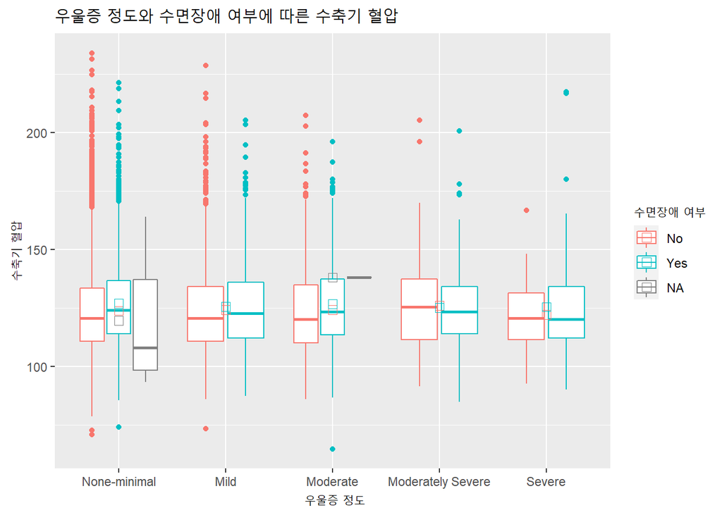

```r
bmx %>% ggplot(aes(x = severity, y = mean_sys, color = SLQ050)) + geom_boxplot() + stat_summary(fun.y="mean", geom="point", shape=22, size=3) +
  labs(title = "우울증 정도와 수면장애 여부에 따른 수축기 혈압", x = " 우울증 정도", y = "수축기 혈압", col = "수면장애 여부")
```

우울증이 심하다고해서 수축기 혈압이 높은 것은 아니었다. 우울증 그룹은 모두 거의 비슷한 분포를 보였다. 하지만, 수면장애와 수축기 혈압은 주목할만한 관계가 있다 생각한다. moderately severe 그룹을 제외하고, 모두 수면장애가 있는 그룹의 평균적인 수축기 혈압이 높았으며, IQR의 범위 역시 수면장애가 있는 그룹이 높게 나타났다.

# Q13

```r
bmx <- bmx %>% mutate(lsys = log2(mean_sys), lbmi = log2(BMXBMI))
mod_bmx <- lm(lsys ~ lbmi, data = bmx)
```

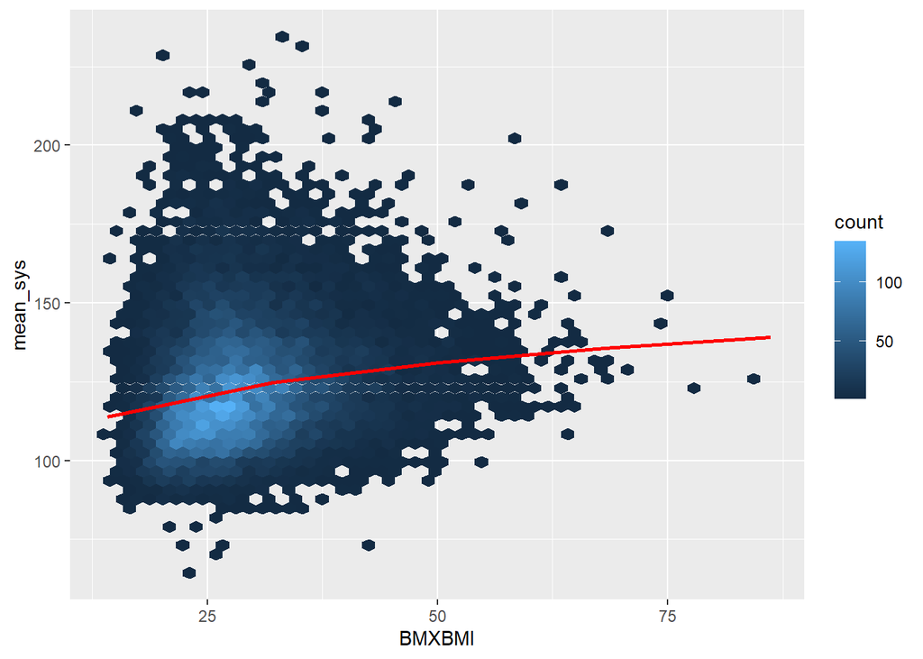

```r
grid <- bmx %>% data_grid(BMXBMI = seq_range(BMXBMI, 5)) %>%
  mutate(lbmi = log2(BMXBMI)) %>%
  add_predictions(mod_bmx, "lsys") %>%
  mutate(mean_sys = 2 ^ lsys)

ggplot(bmx, aes(BMXBMI, mean_sys)) +
  geom_hex(bins = 50) +
  geom_line(data = grid, colour = "red", size = 1)
```

```r
grid <- bmx %>%
  data_grid(lbmi, .model = mod_bmx) %>%
  add_predictions(mod_bmx)
grid
```

```
## # A tibble: 475 × 2
##     lbmi  pred
##    <dbl> <dbl>
##  1  3.82  6.83
##  2  3.83  6.83
##  3  3.86  6.84
##  4  3.89  6.84
##  5  3.90  6.84
##  6  3.92  6.84
##  7  3.93  6.84
##  8  3.94  6.85
##  9  3.95  6.85
## 10  3.96  6.85
## # … with 465 more rows
```